# Microplate reader data analysis

Guilherme Marcelino Viana de Siqueira and María-Eugenia Guazzaroni

November, 2022

## About this analysis

This analysis depends on the `data/growth_curves` subdirectory found in the root directory for this project and on the `mipreadr` *ad-hoc* package that is available through [GitHub](https://github.com/viana-guilherme/mipreadr). The `growth_curves/` subdirectory contain data from different microbial growth experiments. In each experiment, the plate contained at least two biological replicates (from different colonies) of *E. coli* DH10B and/or *P. putida* KT2440 and three technical replicates (repeated wells) for each biological replicate. The `.txt` files in the data directory comes directly from a Perkin Elmer Victor X3 machine set to read absorbance and fluorescence at periodic time points. The `.xlsx` files are the 96-well plate designs used in each experiment, and are needed for the mipreadr workflow

## Set up

To start the analysis, we must first load the required packages. If needed, uncomment the line starting with `remotes::install_github()` to install the development version of mipreadr before loading it.

```r
library(tidyverse)    # loads the tidyverse...

#remotes::install_github("viana-guilherme/mipreadr")
library(mipreadr)     # loads the analysis package

# the packages below are also used through this analysis, be sure to have those installed
library(ggtext)       # used for plotting
library(gt)           # used for helping define the color palettes
library(ggh4x)        # used for plotting
library(multcompView) # used for getting significance levels as letters in the Tukey test
```

## Importing data

This is straightforward using the mipreadr workflow. We first read the files into R using the `addPlate()` function, which also subtracts the blank values from the experimental wells and averages the technical replicates based on the plate layouts provided. The `normalizeFluorescence` argument passed to this function generates a new column for GFP/OD values that will be useful for comparing relative fluorescence levels across samples. After this, the biological samples from different experiments are collapsed with `mergePlates()`, which takes a list of experiments as its sole parameter.

```r
# reading the VictorX3 data into R using the mipreadr function addPlate()
exp01 <- addPlate(file = "../data/growth_curves/2212.txt",
                  layout = "../data/growth_curves/2212.xlsx",
                  mode = "x3",
                  normalizeFluorescence = TRUE)

exp02 <- addPlate(file = "../data/growth_curves/2213.txt",
                  layout = "../data/growth_curves/2213.xlsx",
                  mode = "x3",
                  normalizeFluorescence = TRUE)

exp03 <- addPlate(file = "../data/growth_curves/2220.txt",
                  layout = "../data/growth_curves/2220.xlsx",
                  mode = "x3",
                  normalizeFluorescence = TRUE)

# preparing the list of experiments for analysis
exp_list <- list(exp01, exp02, exp03)

# collapsing the eperiment data with mergePlates()
analysis <- mergePlates(exp_list)

# checking the first few lines of the resulting data frame
head(analysis)
```

```
## # A tibble: 6 × 9
##   Sample         Condition Repeat Absor…¹ Absor…² GFP_M…³ GFP_SD norm.…⁴ norm.…⁵
##   <chr>          <chr>      <dbl>   <dbl>   <dbl>   <dbl>  <dbl>   <dbl>   <dbl>
## 1 pSEVA          Ecoli          1  0.0229 1.64e-3    969.   27.2  42498.   3099.
## 2 pSEVA          Pputida        1  0.0103 3.61e-3    919.   56.4  95768.  25652.
## 3 pSEVA.GFP      Ecoli          1  0.0228 3.63e-4    966.   43.4  42421.   2549.
## 4 pSEVA.GFP      Pputida        1  0.0105 1.14e-3    889.   23.6  85574.   9967.
## 5 pSEVA.P100.GFP Ecoli          1  0.0228 7.83e-4   1009    29.3  44334.   2593.
## 6 pSEVA.P100.GFP Pputida        1  0.0144 1.92e-3   7811. 2205.  536480.  91899.
## # … with abbreviated variable names ¹`Absorbance@600_Mean`,
## #   ²`Absorbance@600_SD`, ³GFP_Mean, ⁴norm.GFP_Mean, ⁵norm.GFP_SD
```

## Visualizing growth and normalized fluorescence curves

Once we have successfully read and pre-processed the data, we can explore the results using a variety of visualizations. In the code blocks below, we will plot the growth and the normalized fluorescence curves for the entire experiment.

In order to have more flexibility for plotting, we will append some metadata - including a custom color palette - onto the analysis data frame:

```r
### Define a manual color vector for coloring the plots consistently ----
basecolors <- RColorBrewer::brewer.pal(9, name = "Spectral") |>
  gt::adjust_luminance(steps = -0.1)

colorPalette <- basecolors[c(3:1, 7:9)]

# the modifications below are mainly cosmetic

analysis <- analysis |>
  #this part helps making the names more tidy for the plot
  mutate(uniqueID = glue::glue("{Sample}:{Condition}"),
        readableName = case_when(
              Sample == "pSEVA" ~ "pSEVA231-∅",
              Sample == "pSEVA.GFP" ~ "pSEVA231-*gfplva*",
              Sample == "pSEVA.P100.GFP" ~ "pSEVA231-P*j100*-*gfplva*",
              Sample == "pVANT" ~ "pVANT-∅",
              Sample == "pVANT.GFP" ~ "pVANT-*gfplva*",
              Sample == "pVANT.P100.GFP" ~ "pVANT-P*j100*-*gfplva*"
              ) %>%
          # this part gives us a way to reorder the columns in the barplot
          as_factor() %>%
          fct_relevel(c("pSEVA231-∅",
                        "pSEVA231-*gfplva*",
                        "pSEVA231-P*j100*-*gfplva*",
                        "pVANT-∅",
                        "pVANT-*gfplva*",
                        "pVANT-P*j100*-*gfplva*")
          ),
        # this part helps us plot the species names in italics using ggtext
        readableCondition = case_when(
              Condition == "Ecoli" ~ "*E. coli* DH10B",
              Condition == "Pputida" ~ "*P. putida* KT2440",
              ),
        # this part attaches a specific color from our palette to a given sample
        light_color = case_when(
          readableName == "pSEVA231-∅" ~ colorPalette[1],
          readableName == "pSEVA231-*gfplva*" ~ colorPalette[2],
          readableName == "pSEVA231-P*j100*-*gfplva*" ~ colorPalette[3],
          readableName == "pVANT-∅" ~ colorPalette[4],
          readableName == "pVANT-*gfplva*" ~ colorPalette[5],
          readableName == "pVANT-P*j100*-*gfplva*" ~ colorPalette[6]
          )
  )
```

We also will define a named color vector to consistently color our samples in the plots based on the `light_color` column we just created

```r
custom_colors <- analysis |>
  select(readableName, light_color) |>
  distinct() |>
  deframe() # make a 2-column tibble into a named vector
```

Finally, we can use `ggplot2` to plot the curves. First OD600 *versus* time:

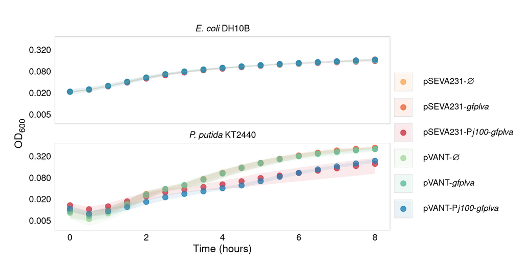

```r
analysis |>
  ggplot(aes(x = Repeat, y = `Absorbance@600_Mean`)) +
  geom_point(aes(color = readableName, fill = readableName),
                 stroke = 0.7, size = 3, alpha = 0.8) +
  geom_ribbon(aes(ymin= `Absorbance@600_Mean` - `Absorbance@600_SD`,
                  ymax= `Absorbance@600_Mean` + `Absorbance@600_SD`,
                  fill = readableName),
              alpha = 0.1) +

  # using a semilogarithmic scale with custom breaks
  scale_y_continuous(trans = "log", breaks = c(0.005, 0.02, 0.08, 0.32)) +
  # the line below converts the timepoints (x-axis) into half-hour periods
  scale_x_continuous(labels = ~ {(.x - 1)/2}, breaks = seq(from = 1, to = 17, by = 4)) +

  # Editing some of the visual aspects of the plot
  labs(x = "Time (hours)", y = "OD<sub>600</sub>") +
  guides(fill = guide_legend(title = "", ncol = 1, byrow = TRUE),
         color = guide_legend(title = "", ncol = 1, byrow = TRUE),
         shape = guide_legend(title = "", ncol = 1, byrow = TRUE),) +
  # below we use our custom palette vectors. In this instance we want color and fill to be the same,
  # so we will repeat it...
  scale_color_manual(values = custom_colors) +
  scale_fill_manual(values = custom_colors) +

  # separates the plot between species
  facet_wrap(~ readableCondition,  strip.position = "top", nrow = 2) +

  # setting up the theme
  theme_light(base_size = 11) +
  theme(
        axis.title.x = element_markdown(size = rel(1.3), color = "black"),
        axis.text.x = element_markdown(size = rel(1.4), color = "black"),
        axis.title.y = element_markdown(size = rel(1.3), color = "black"),
        axis.text.y = element_markdown(size = rel(1.4), color = "black"),

        axis.ticks = element_blank(),
        panel.grid = element_blank(),
        plot.margin = unit(c(30,10,10,20), "pt"),

        legend.spacing.y = unit(10, "pt"),
        legend.spacing.x = unit(15, "pt"),
        legend.box.spacing = unit(0, "pt"),
        legend.position = "right",
        legend.key = element_rect(color = "grey60", size = 0.1),
        legend.key.size = unit(25, "pt"),
        legend.box.margin = margin(12,0,0,0, unit = "pt"),
        legend.text = ggtext::element_markdown(size = rel(1.05)),

        strip.background = element_blank(),
        strip.text = ggtext::element_markdown(color = "black", size = rel(1.1)),
        strip.placement = "outside"
        )
```

And we may also plot the normalized fluorescence curve:

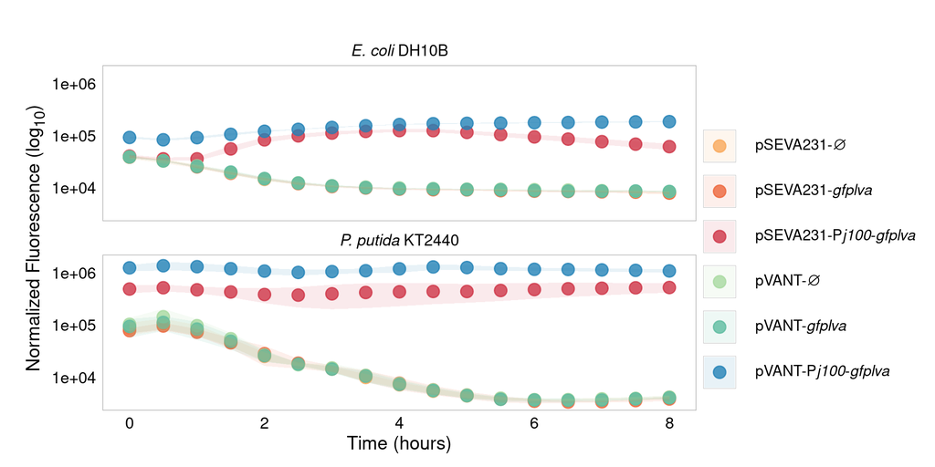

```r
analysis |>
  ggplot(aes(x = Repeat, y = `norm.GFP_Mean`)) +
  geom_point(aes(color = readableName, fill = readableName),
             stroke = 0.7, size = 4, alpha = 0.8) +
  geom_ribbon(aes(ymin = `norm.GFP_Mean` - `norm.GFP_SD`,
                  ymax = `norm.GFP_Mean` + `norm.GFP_SD`,
                  fill = readableName),
              alpha = 0.1) +
  scale_y_continuous(trans = "log10") +
  scale_x_continuous(labels = ~ {(.x - 1)/2}, breaks = seq(from = 1, to = 17, by = 4)) +
  labs(x = "Time (hours)", y = "Normalized Fluorescence (log<sub>10</sub>)") +
  guides(fill = guide_legend(title = "", ncol = 1, byrow = TRUE),
         color = guide_legend(title = "", ncol = 1, byrow = TRUE),
         shape = guide_legend(title = "", ncol = 1, byrow = TRUE),) +
  scale_color_manual(values = custom_colors) +
  scale_fill_manual(values = custom_colors) +
  facet_wrap(~ readableCondition,  strip.position = "top", nrow = 2) +
  theme_light(base_size = 11) +
  theme(axis.title.x = ggtext::element_markdown(size = rel(1.3), color = "black"),
        axis.text.x = ggtext::element_markdown(size = rel(1.4), color = "black"),
        axis.title.y = ggtext::element_markdown(size = rel(1.3), color = "black"),
        axis.text.y = ggtext::element_markdown(size = rel(1.4), color = "black"),

        axis.ticks = element_blank(),
        panel.grid = element_blank(),
        plot.margin = unit(c(30,10,10,20), "pt"),

        legend.spacing.y = unit(10, "pt"),
        legend.spacing.x = unit(15, "pt"),
        legend.box.spacing = unit(0, "pt"),
        legend.position = "right",
        legend.key = element_rect(color = "grey60", size = 0.1),
        legend.key.size = unit(25, "pt"),
        legend.box.margin = margin(12,0,0,0, unit = "pt"),
        legend.text = ggtext::element_markdown(size = rel(1.05)),

        strip.background = element_blank(),
        strip.text = ggtext::element_markdown(color = "black", size = rel(1.1)),
        strip.placement = "outside")
```